# Dissemination using Quarto and Github Pages

Dr James Bartlett  
University of Glasgow  
@bartlettje.bsky.social  
Data Upskilling Workshop

## Preparation steps

- R/RStudio downloaded to your laptop ✔️
  - At least RStudio v2022.07 or later
- A github account if you do not have one already ✔️
  - Consider applying for an education account!
- Download github desktop to access git and a graphical user interface (GUI) ✔️

## Why share you/your work?

- Although credit/incentives are not always optimal, open materials/tutorials benefit science ([PsyTeachR Team, 2022](https://www.nature.com/articles/s44159-022-00058-8)).
- Academics need to work on self-branding to build your profile and reputation ([Dijkstra, 2022](https://www.timeshighereducation.com/campus/building-your-research-profile-social-media-focus-linkedin)).
- “For the love of God, share what you do” ([Nordmann, 2025](https://www.emilynordmann.com/post/supporting-scholarship-in-yourself-and-others/)).

# Key terminology

## Quarto

- **Quarto** = scientific and technical publishing system to combine text and code.
  - **Render** = generate a new file that combines text, code, and output.

## github

- **github** = a developer platform for managing and sharing code.
  - **git** = a version control system to track code/files.
  - **Repository** = a folder containing a saved version of your code.
  - **Pull** = retrieve the current version of code in a repository.
  - **Commit** = save any current changes to code.
  - **Push** = upload your changes to your repository.

## Quarto workflow

[figure not shown]

## Dissemination workflow

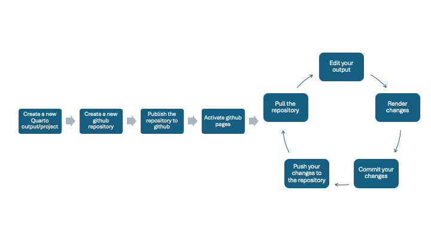